# **Project_Group9**

Akshatha Ganji Sree Ram Charan Pammi Kodi Manu Aithal

2023-04-21

```r
# Import needed packages
library(tidyverse)
library(ggplot2)
library(tigerstats)
library(reticulate)
library(MASS)
library(MLmetrics)
library(dplyr)
```

```r
LungCancer<- read.csv("C:/Users/aksha/Downloads/archive/survey lung cancer.csv", sep=",")
view(LungCancer)
summary(LungCancer)
```

```
##     GENDER               AGE           SMOKING      YELLOW_FINGERS
##  Length:309         Min.   :21.00   Min.   :1.000   Min.   :1.00
##  Class :character   1st Qu.:57.00   1st Qu.:1.000   1st Qu.:1.00
##  Mode  :character   Median :62.00   Median :2.000   Median :2.00
##                     Mean   :62.67   Mean   :1.563   Mean   :1.57
##                     3rd Qu.:69.00   3rd Qu.:2.000   3rd Qu.:2.00
##                     Max.   :87.00   Max.   :2.000   Max.   :2.00
##     ANXIETY      PEER_PRESSURE   CHRONIC.DISEASE    FATIGUE
##  Min.   :1.000   Min.   :1.000   Min.   :1.000   Min.   :1.000
##  1st Qu.:1.000   1st Qu.:1.000   1st Qu.:1.000   1st Qu.:1.000
##  Median :1.000   Median :2.000   Median :2.000   Median :2.000
##  Mean   :1.498   Mean   :1.502   Mean   :1.505   Mean   :1.673
##  3rd Qu.:2.000   3rd Qu.:2.000   3rd Qu.:2.000   3rd Qu.:2.000
##  Max.   :2.000   Max.   :2.000   Max.   :2.000   Max.   :2.000
##     ALLERGY         WHEEZING     ALCOHOL.CONSUMING    COUGHING
##  Min.   :1.000   Min.   :1.000   Min.   :1.000     Min.   :1.000
##  1st Qu.:1.000   1st Qu.:1.000   1st Qu.:1.000     1st Qu.:1.000
##  Median :2.000   Median :2.000   Median :2.000     Median :2.000
##  Mean   :1.557   Mean   :1.557   Mean   :1.557     Mean   :1.579
##  3rd Qu.:2.000   3rd Qu.:2.000   3rd Qu.:2.000     3rd Qu.:2.000
##  Max.   :2.000   Max.   :2.000   Max.   :2.000     Max.   :2.000
##  SHORTNESS.OF.BREATH SWALLOWING.DIFFICULTY   CHEST.PAIN    LUNG_CANCER
##  Min.   :1.000       Min.   :1.000         Min.   :1.000   Length:309
##  1st Qu.:1.000       1st Qu.:1.000         1st Qu.:1.000   Class :character
##  Median :2.000       Median :1.000         Median :2.000   Mode  :character
##  Mean   :1.641       Mean   :1.469         Mean   :1.557
##  3rd Qu.:2.000       3rd Qu.:2.000         3rd Qu.:2.000
##  Max.   :2.000       Max.   :2.000         Max.   :2.000
```

```r
dim(LungCancer)
```

```
## [1] 309  16
```

The lung cancer data set has 309 rows and 16 columns.

```r
str(LungCancer)
```

```
## 'data.frame':    309 obs. of  16 variables:
##  $ GENDER               : chr  "M" "M" "F" "M" ...
##  $ AGE                  : int  69 74 59 63 63 75 52 51 68 53 ...
##  $ SMOKING              : int  1 2 1 2 1 1 2 2 2 2 ...
##  $ YELLOW_FINGERS       : int  2 1 1 2 2 2 1 2 1 2 ...
##  $ ANXIETY              : int  2 1 1 2 1 1 1 2 2 2 ...
##  $ PEER_PRESSURE        : int  1 1 2 1 1 1 1 2 1 2 ...
##  $ CHRONIC.DISEASE      : int  1 2 1 1 1 2 1 1 1 2 ...
##  $ FATIGUE              : int  2 2 2 1 1 2 2 2 2 1 ...
##  $ ALLERGY              : int  1 2 1 1 1 2 1 2 1 2 ...
##  $ WHEEZING             : int  2 1 2 1 2 2 2 1 1 1 ...
##  $ ALCOHOL.CONSUMING    : int  2 1 1 2 1 1 2 1 1 2 ...
##  $ COUGHING             : int  2 1 2 1 2 2 2 1 1 1 ...
##  $ SHORTNESS.OF.BREATH  : int  2 2 2 1 2 2 2 2 1 1 ...
##  $ SWALLOWING.DIFFICULTY: int  2 2 1 2 1 1 1 2 1 2 ...
##  $ CHEST.PAIN           : int  2 2 2 2 1 1 2 1 1 2 ...
##  $ LUNG_CANCER          : chr  "YES" "YES" "NO" "NO" ...
```

The data types covered are int and character . It has fourteen numerical attribute and two strings.

```r
sum(is.na(LungCancer))
```

```
## [1] 0
```

There are no missing values in the dataset.

```r
mean(LungCancer$AGE)
```

```
## [1] 62.67314
```

```r
min(LungCancer$AGE)
```

```
## [1] 21
```

```r
max(LungCancer$AGE)
```

```
## [1] 87
```

This proves that there must be additional factors contributing to the presence of lung cancer in the population sample given.

```r
df <- data.frame(
  x = c(LungCancer$SMOKING),
  y = c(LungCancer$YELLOW_FINGERS),
  z = c(LungCancer$ANXIETY),
  a=c(LungCancer$PEER_PRESSURE),
  b=c(LungCancer$CHRONIC.DISEASE),
  d=c(LungCancer$FATIGUE)
)
num_2 <- sapply(df, function(col) sum(col == 2))

# Print the number of 2 values in each column
print(num_2)
```

```
##   x   y   z   a   b   d
## 174 176 154 155 156 208
```

It shows that the predominant feature that might be contributing to the lung cancer is fatigue since it is seen in larger value of the population.

**EXPLORATORY DATA ANALYSIS**

**HISTOGRAM**

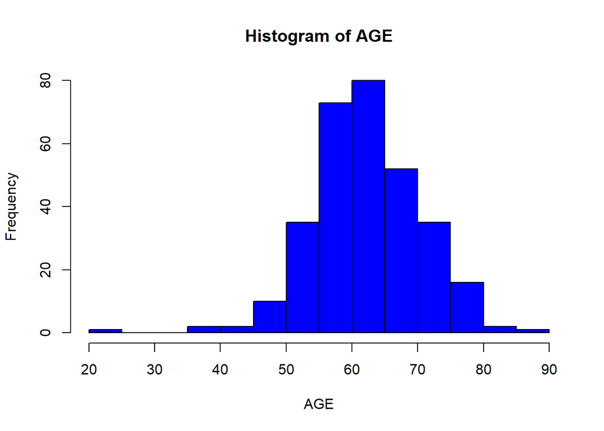

```r
hist(LungCancer$AGE, breaks = 20, col = "blue", main = "Histogram of AGE",xlab="AGE")
```

It depicts the age attribute in which the population is normally distributed around the age 40-90.

**BOXPLOT**

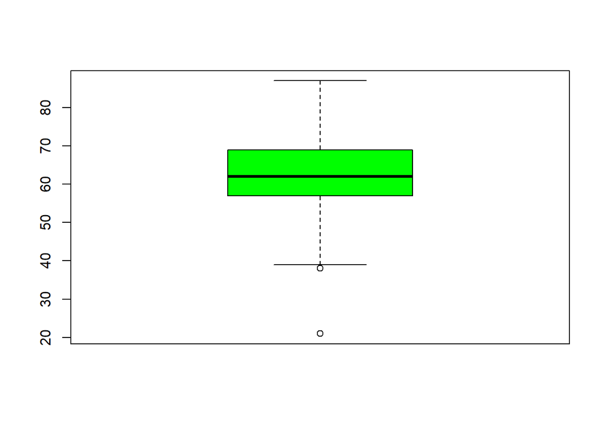

```r
boxplot(LungCancer$AGE, horizontal = FALSE,col = "green")
```

In the box plot above it depicts that the median age value lies around 62, there are a few outliers that range around 20 and 38 , the maximum value goes up-to 87.The first quantile ranges from 40-58, the middle 50% quantile ranges from 58-70 covering the median value,the last quantile ranges from 68-87.

**BARPLOT**

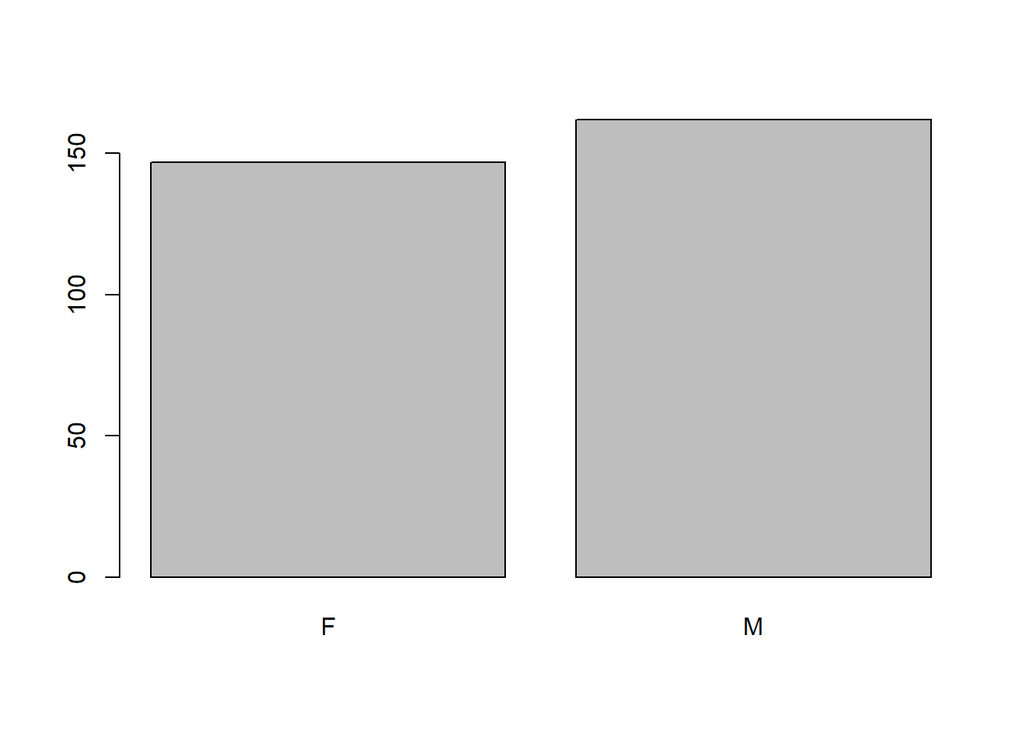

```r
barplot(table(LungCancer$GENDER))
```

There are more male who have been taken into consideration for the sample space, than the number of female.

**SCATTERPLOT**

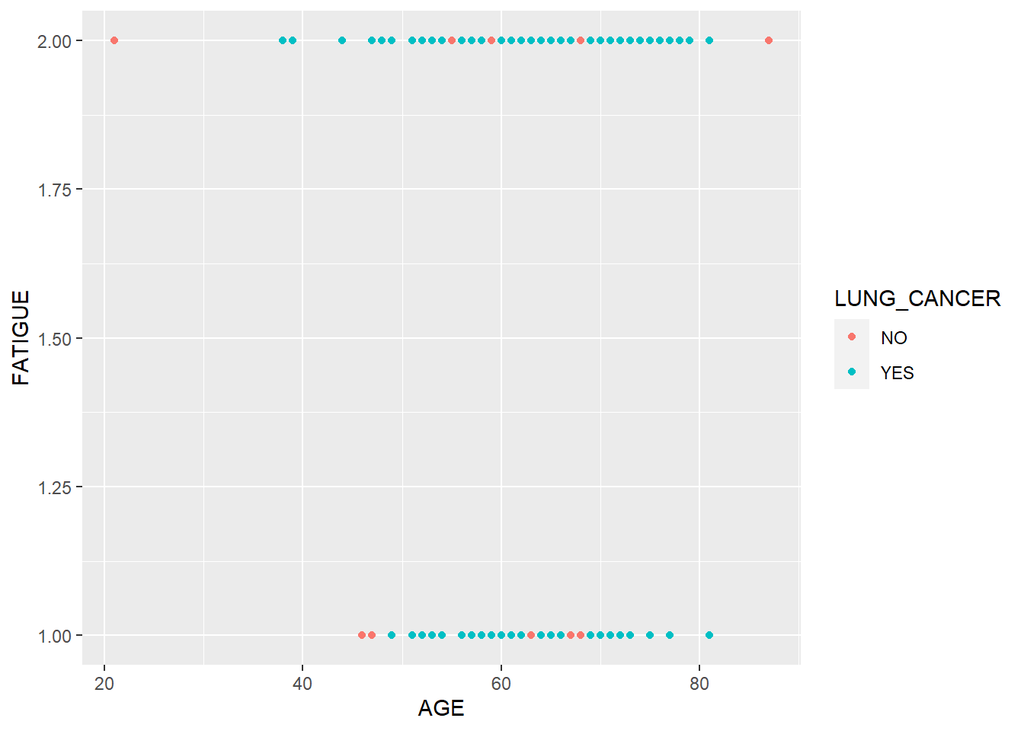

```r
ggplot(data = LungCancer) +
  geom_point(mapping = aes(x = AGE, y = FATIGUE, colour = LUNG_CANCER))
```

**OVERLAY HISTOGRAM**

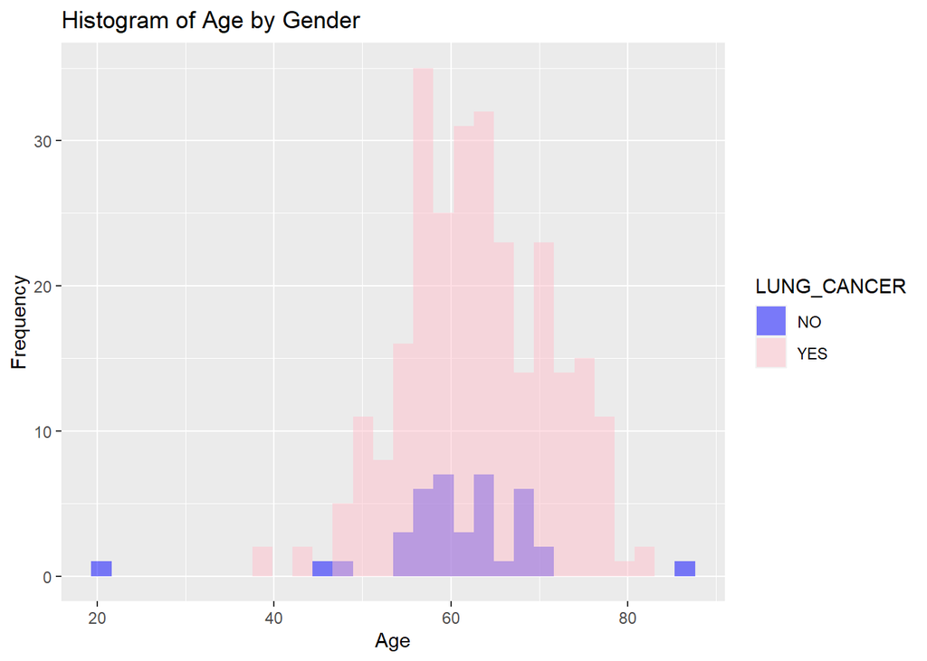

```r
ggplot(LungCancer, aes(x = AGE, fill = LUNG_CANCER)) +
  geom_histogram(alpha = 0.5, position = "identity", bins = 30) +
  labs(title = "Histogram of Age by Gender", x = "Age", y = "Frequency") +
  scale_fill_manual(values = c("blue", "pink"))
```

**Hypothesis Test:**

Null Hypothesis: There is no difference in variances between the two genders.

```r
male_age <- LungCancer[LungCancer$GENDER == "M", "AGE"]
female_age <- LungCancer[LungCancer$GENDER == "F", "AGE"]
var.test(male_age,female_age)
```

```
##
##  F test to compare two variances
##
## data:  male_age and female_age
## F = 0.68359, num df = 161, denom df = 146, p-value = 0.01864
## alternative hypothesis: true ratio of variances is not equal to 1
## 95 percent confidence interval:
##  0.4967864 0.9382978
## sample estimates:
## ratio of variances
##          0.6835941
```

The F-test compares the variances of two samples to determine whether they are statistically different. The output shows that the p-value is 0.01864, which is less than the significance level of 0.05. Therefore, we can reject the null hypothesis that the variances of the two groups are equal.

The alternative hypothesis is that the true ratio of variances is not equal to 1. The 95% confidence interval for the ratio of variances is (0.4967864, 0.9382978), which does not include 1. This further supports the rejection of the null hypothesis.

In conclusion, we can reject the null hypothesis and conclude that the variances of the male and female age groups are statistically different.

Null Hypothesis: There is no difference in mean age of between the two genders.

```r
# Subset data set by gender
male_age <- LungCancer[LungCancer$GENDER == "M", "AGE"]
female_age <- LungCancer[LungCancer$GENDER == "F", "AGE"]

# Conduct two-sample t-test
t.test(male_age, female_age, var.equal = FALSE)
```

```
##
##  Welch Two Sample t-test
##
## data:  male_age and female_age
## t = 0.37, df = 284.16, p-value = 0.7117
## alternative hypothesis: true difference in means is not equal to 0
## 95 percent confidence interval:
##  -1.510692  2.210112
## sample estimates:
## mean of x mean of y
##  62.83951  62.48980
```

**Simple Linear Regression**

```r
train_index = sample(2,nrow(LungCancer),replace=TRUE, prob = c(0.8,0.2))
LungTraining <- LungCancer[train_index==1,]
LungTest <- LungCancer[train_index==2,]
dim(LungTraining)
```

```
## [1] 246  16
```

```r
dim(LungTest)
```

```
## [1] 63 16
```

Dividing the dataset into two parts.

Regression:Modelling the relationship between dependent variable and one or more independent variables.

```r
# Perform a simple linear regression with "age" as the predictor variable and "bronchitis" as the response variable
lm_model <- lm(COUGHING ~ AGE, data = LungTraining)

# Print the summary of the linear regression model
summary(lm_model)
```

```
##
## Call:
## lm(formula = COUGHING ~ AGE, data = LungTraining)
##
## Residuals:
##     Min      1Q  Median      3Q     Max
## -0.8147 -0.5565  0.3274  0.4127  0.6496
##
## Coefficients:
##             Estimate Std. Error t value Pr(>|t|)
## (Intercept) 0.990241   0.235647   4.202 3.71e-05 ***
## AGE         0.009477   0.003720   2.548   0.0115 *
## ---
## Signif. codes:  0 '***' 0.001 '**' 0.01 '*' 0.05 '.' 0.1 ' ' 1
##
## Residual standard error: 0.4882 on 244 degrees of freedom
## Multiple R-squared:  0.02591,    Adjusted R-squared:  0.02192
## F-statistic: 6.491 on 1 and 244 DF,  p-value: 0.01145
```

In summary, the linear regression model shows that there is a statistically significant positive relationship between age and coughing in lung cancer patients.

```r
predictions <- predict(lm_model, newdata = LungTest)
summary(predictions)
```

```
##    Min. 1st Qu.  Median    Mean 3rd Qu.    Max.
##   1.426   1.540   1.568   1.580   1.635   1.720
```

```r
# Calculate the mean absolute error (MAE)
MAE(y_pred = predictions, y_true = LungTest$COUGHING)
```

```
## [1] 0.4766119
```

```r
# Calculate the mean squared error (MSE)
MSE(y_pred = predictions, y_true = LungTest$COUGHING)
```

```
## [1] 0.2379633
```

MAE: Mean absolute error, measure of average mistake in a collection of prediction. MSE:Average squared difference between estimated values and actual value.

Multiple Linear Regression:

```r
mlm_model <- lm(COUGHING ~ ., data = LungTraining)
# Print the summary of the multiple linear regression model
summary(mlm_model)
```

```
##
## Call:
## lm(formula = COUGHING ~ ., data = LungTraining)
##
## Residuals:
##      Min       1Q   Median       3Q      Max
## -0.85019 -0.29090  0.02121  0.30088  0.85229
##
## Coefficients:
##                        Estimate Std. Error t value Pr(>|t|)
## (Intercept)            0.266697   0.339116   0.786 0.432414
## GENDERM                0.043074   0.061404   0.701 0.483711
## AGE                    0.009714   0.003050   3.185 0.001648 **
## SMOKING               -0.076852   0.054478  -1.411 0.159687
## YELLOW_FINGERS         0.252730   0.065861   3.837 0.000161 ***
## ANXIETY               -0.188128   0.070209  -2.680 0.007905 **
## PEER_PRESSURE          0.032546   0.060767   0.536 0.592756
## CHRONIC.DISEASE       -0.179107   0.055217  -3.244 0.001355 **
## FATIGUE               -0.082855   0.065574  -1.264 0.207679
## ALLERGY                0.030666   0.061501   0.499 0.618516
## WHEEZING               0.205841   0.057645   3.571 0.000433 ***
## ALCOHOL.CONSUMING      0.221583   0.072194   3.069 0.002403 **
## SHORTNESS.OF.BREATH    0.326432   0.061740   5.287 2.88e-07 ***
## SWALLOWING.DIFFICULTY -0.229223   0.065406  -3.505 0.000550 ***
## CHEST.PAIN            -0.033921   0.058129  -0.584 0.560099
## LUNG_CANCERYES         0.210588   0.097239   2.166 0.031364 *
## ---
## Signif. codes:  0 '***' 0.001 '**' 0.01 '*' 0.05 '.' 0.1 ' ' 1
##
## Residual standard error: 0.394 on 230 degrees of freedom
## Multiple R-squared:  0.4021, Adjusted R-squared:  0.3632
## F-statistic: 10.31 on 15 and 230 DF,  p-value: < 2.2e-16
```

```r
summary(mlm_model)
```

```
##
## Call:
## lm(formula = COUGHING ~ ., data = LungTraining)
##
## Residuals:
##      Min       1Q   Median       3Q      Max
## -0.85019 -0.29090  0.02121  0.30088  0.85229
##
## Coefficients:
##                        Estimate Std. Error t value Pr(>|t|)
## (Intercept)            0.266697   0.339116   0.786 0.432414
## GENDERM                0.043074   0.061404   0.701 0.483711
## AGE                    0.009714   0.003050   3.185 0.001648 **
## SMOKING               -0.076852   0.054478  -1.411 0.159687
## YELLOW_FINGERS         0.252730   0.065861   3.837 0.000161 ***
## ANXIETY               -0.188128   0.070209  -2.680 0.007905 **
## PEER_PRESSURE          0.032546   0.060767   0.536 0.592756
## CHRONIC.DISEASE       -0.179107   0.055217  -3.244 0.001355 **
## FATIGUE               -0.082855   0.065574  -1.264 0.207679
## ALLERGY                0.030666   0.061501   0.499 0.618516
## WHEEZING               0.205841   0.057645   3.571 0.000433 ***
## ALCOHOL.CONSUMING      0.221583   0.072194   3.069 0.002403 **
## SHORTNESS.OF.BREATH    0.326432   0.061740   5.287 2.88e-07 ***
## SWALLOWING.DIFFICULTY -0.229223   0.065406  -3.505 0.000550 ***
## CHEST.PAIN            -0.033921   0.058129  -0.584 0.560099
## LUNG_CANCERYES         0.210588   0.097239   2.166 0.031364 *
## ---
## Signif. codes:  0 '***' 0.001 '**' 0.01 '*' 0.05 '.' 0.1 ' ' 1
##
## Residual standard error: 0.394 on 230 degrees of freedom
## Multiple R-squared:  0.4021, Adjusted R-squared:  0.3632
## F-statistic: 10.31 on 15 and 230 DF,  p-value: < 2.2e-16
```

```r
predict <- predict(mlm_model, newdata =LungTest)
summary(predict)
```

```
##    Min. 1st Qu.  Median    Mean 3rd Qu.    Max.
##  0.8378  1.3159  1.5080  1.5421  1.7201  2.4525
```

```r
MAE(y_pred = predictions, y_true = LungTest$COUGHING)
```

```
## [1] 0.4766119
```

```r
MSE(y_pred = predictions, y_true = LungTest$COUGHING)
```

```
## [1] 0.2379633
```

### Forward Stepwise

```r
library(MASS)
# Create a null model
intercept_only <- lm(COUGHING ~ 1, data=LungTraining)
# Create a full model
all <- lm(COUGHING~., data=LungTraining)
# perform forward step-wise regression
forward <- stepAIC (intercept_only, direction='forward',scope = formula(all))
```

```
## Start:  AIC=-346.31
## COUGHING ~ 1
##
##                         Df Sum of Sq    RSS     AIC
## + WHEEZING               1    6.6435 53.064 -373.32
## + SHORTNESS.OF.BREATH    1    5.0017 54.706 -365.83
## + ALCOHOL.CONSUMING      1    3.8949 55.812 -360.90
## + ANXIETY                1    3.4976 56.210 -359.16
## + LUNG_CANCER            1    3.4703 56.237 -359.04
## + SWALLOWING.DIFFICULTY  1    2.7640 56.943 -355.97
## + ALLERGY                1    2.2956 57.412 -353.95
## + GENDER                 1    1.9776 57.730 -352.59
## + AGE                    1    1.5473 58.160 -350.76
## + CHEST.PAIN             1    1.1151 58.592 -348.94
## + CHRONIC.DISEASE        1    1.0858 58.621 -348.82
## + PEER_PRESSURE          1    0.7408 58.967 -347.38
## + FATIGUE                1    0.6585 59.049 -347.03
## + SMOKING                1    0.5871 59.120 -346.74
## <none>                               59.707 -346.31
## + YELLOW_FINGERS         1    0.0006 59.707 -344.31
##
## Step:  AIC=-373.32
## COUGHING ~ WHEEZING
##
##                         Df Sum of Sq    RSS     AIC
## + SHORTNESS.OF.BREATH    1    4.2800 48.784 -392.01
## + SWALLOWING.DIFFICULTY  1    3.5327 49.531 -388.27
## + ANXIETY                1    1.6982 51.366 -379.33
## + ALCOHOL.CONSUMING      1    1.6610 51.403 -379.15
## + LUNG_CANCER            1    1.5560 51.508 -378.65
## + AGE                    1    1.3898 51.674 -377.85
## + CHRONIC.DISEASE        1    1.2144 51.849 -377.02
## + ALLERGY                1    1.1185 51.945 -376.56
## + GENDER                 1    0.9153 52.149 -375.60
## <none>                               53.064 -373.32
## + PEER_PRESSURE          1    0.3916 52.672 -373.15
## + CHEST.PAIN             1    0.3906 52.673 -373.14
## + FATIGUE                1    0.2385 52.825 -372.43
## + SMOKING                1    0.1965 52.867 -372.24
## + YELLOW_FINGERS         1    0.0543 53.010 -371.58
```

[output cut: 117 more lines]

```
## + FATIGUE        1   0.02184 37.004 -446.00
##
## Step:  AIC=-450.35
## COUGHING ~ WHEEZING + SHORTNESS.OF.BREATH + ALCOHOL.CONSUMING +
##     SWALLOWING.DIFFICULTY + YELLOW_FINGERS + AGE + ANXIETY +
##     CHRONIC.DISEASE + LUNG_CANCER
##
##                 Df Sum of Sq    RSS     AIC
## <none>                       36.356 -450.35
## + SMOKING        1  0.271442 36.085 -450.19
## + FATIGUE        1  0.167654 36.188 -449.48
## + CHEST.PAIN     1  0.066738 36.289 -448.80
## + GENDER         1  0.031261 36.325 -448.56
## + ALLERGY        1  0.014011 36.342 -448.44
## + PEER_PRESSURE  1  0.008591 36.347 -448.40
```

```r
forward$anova
```

```
## Stepwise Model Path
## Analysis of Deviance Table
##
## Initial Model:
## COUGHING ~ 1
##
## Final Model:
## COUGHING ~ WHEEZING + SHORTNESS.OF.BREATH + ALCOHOL.CONSUMING +
##     SWALLOWING.DIFFICULTY + YELLOW_FINGERS + AGE + ANXIETY +
##     CHRONIC.DISEASE + LUNG_CANCER
##
##
##                       Step Df  Deviance Resid. Df Resid. Dev       AIC
## 1                                             245   59.70732 -346.3057
## 2               + WHEEZING  1 6.6435071       244   53.06381 -373.3238
## 3    + SHORTNESS.OF.BREATH  1 4.2799948       243   48.78382 -392.0115
## 4      + ALCOHOL.CONSUMING  1 3.0453928       242   45.73842 -405.8686
## 5  + SWALLOWING.DIFFICULTY  1 2.3969296       241   43.34149 -417.1104
## 6         + YELLOW_FINGERS  1 2.4260628       240   40.91543 -429.2808
## 7                    + AGE  1 1.5878740       239   39.32756 -437.0179
## 8                + ANXIETY  1 1.0129082       238   38.31465 -441.4368
## 9        + CHRONIC.DISEASE  1 1.2891748       237   37.02547 -447.8564
## 10           + LUNG_CANCER  1 0.6694462       236   36.35603 -450.3450
```

```r
summary(forward)
```

```
##
## Call:
## lm(formula = COUGHING ~ WHEEZING + SHORTNESS.OF.BREATH + ALCOHOL.CONSUMING +
##     SWALLOWING.DIFFICULTY + YELLOW_FINGERS + AGE + ANXIETY +
##     CHRONIC.DISEASE + LUNG_CANCER, data = LungTraining)
##
## Residuals:
##      Min       1Q   Median       3Q      Max
## -0.83000 -0.31160  0.02076  0.29781  0.88173
##
## Coefficients:
##                       Estimate Std. Error t value Pr(>|t|)
## (Intercept)            0.01088    0.27777   0.039 0.968785
## WHEEZING               0.20348    0.05624   3.618 0.000363 ***
## SHORTNESS.OF.BREATH    0.28730    0.05628   5.105 6.82e-07 ***
## ALCOHOL.CONSUMING      0.26265    0.05922   4.435 1.41e-05 ***
## SWALLOWING.DIFFICULTY -0.22110    0.06160  -3.589 0.000403 ***
## YELLOW_FINGERS         0.27462    0.06329   4.339 2.12e-05 ***
## AGE                    0.01026    0.00302   3.399 0.000795 ***
## ANXIETY               -0.20178    0.06768  -2.981 0.003171 **
## CHRONIC.DISEASE       -0.15562    0.05091  -3.057 0.002495 **
## LUNG_CANCERYES         0.18037    0.08653   2.085 0.038180 *
## ---
## Signif. codes:  0 '***' 0.001 '**' 0.01 '*' 0.05 '.' 0.1 ' ' 1
##
## Residual standard error: 0.3925 on 236 degrees of freedom
## Multiple R-squared:  0.3911, Adjusted R-squared:  0.3679
## F-statistic: 16.84 on 9 and 236 DF,  p-value: < 2.2e-16
```

```r
library(ISLR)
ypred_forward <-predict(object = forward, newdata = LungTest)
MAE(y_pred = ypred_forward, y_true = LungTest$COUGHING)
```

```
## [1] 0.4049294
```

```r
MSE(y_pred = ypred_forward, y_true = LungTest$COUGHING)
```

```
## [1] 0.213412
```

## Backward Stepwise:

```r
backward <- stepAIC (all, direction='backward')
```

```
## Start:  AIC=-442.85
## COUGHING ~ GENDER + AGE + SMOKING + YELLOW_FINGERS + ANXIETY +
##     PEER_PRESSURE + CHRONIC.DISEASE + FATIGUE + ALLERGY + WHEEZING +
##     ALCOHOL.CONSUMING + SHORTNESS.OF.BREATH + SWALLOWING.DIFFICULTY +
##     CHEST.PAIN + LUNG_CANCER
##
##                         Df Sum of Sq    RSS     AIC
## - ALLERGY                1    0.0386 35.735 -444.58
## - PEER_PRESSURE          1    0.0445 35.741 -444.54
## - CHEST.PAIN             1    0.0529 35.749 -444.48
## - GENDER                 1    0.0764 35.773 -444.32
## - FATIGUE                1    0.2478 35.944 -443.15
## <none>                               35.697 -442.85
## - SMOKING                1    0.3089 36.005 -442.73
## - LUNG_CANCER            1    0.7279 36.424 -439.88
## - ANXIETY                1    1.1143 36.811 -437.29
## - ALCOHOL.CONSUMING      1    1.4621 37.159 -434.97
## - AGE                    1    1.5744 37.271 -434.23
## - CHRONIC.DISEASE        1    1.6330 37.330 -433.84
## - SWALLOWING.DIFFICULTY  1    1.9062 37.603 -432.05
## - WHEEZING               1    1.9790 37.676 -431.58
## - YELLOW_FINGERS         1    2.2854 37.982 -429.58
## - SHORTNESS.OF.BREATH    1    4.3387 40.035 -416.63
##
## Step:  AIC=-444.58
## COUGHING ~ GENDER + AGE + SMOKING + YELLOW_FINGERS + ANXIETY +
##     PEER_PRESSURE + CHRONIC.DISEASE + FATIGUE + WHEEZING + ALCOHOL.CONSUMING +
##     SHORTNESS.OF.BREATH + SWALLOWING.DIFFICULTY + CHEST.PAIN +
##     LUNG_CANCER
##
##                         Df Sum of Sq    RSS     AIC
## - PEER_PRESSURE          1    0.0410 35.776 -446.30
## - CHEST.PAIN             1    0.0455 35.781 -446.27
## - GENDER                 1    0.0719 35.807 -446.09
## - FATIGUE                1    0.2386 35.974 -444.95
## <none>                               35.735 -444.58
## - SMOKING                1    0.3011 36.036 -444.52
## - LUNG_CANCER            1    0.9013 36.636 -440.45
## - ANXIETY                1    1.1546 36.890 -438.76
## - AGE                    1    1.5939 37.329 -435.85
```

[output cut: 87 more lines]

```
## COUGHING ~ AGE + YELLOW_FINGERS + ANXIETY + CHRONIC.DISEASE +
##     WHEEZING + ALCOHOL.CONSUMING + SHORTNESS.OF.BREATH + SWALLOWING.DIFFICULTY +
##     LUNG_CANCER
##
##                         Df Sum of Sq    RSS     AIC
## <none>                               36.356 -450.35
## - LUNG_CANCER            1    0.6694 37.025 -447.86
## - ANXIETY                1    1.3693 37.725 -443.25
## - CHRONIC.DISEASE        1    1.4394 37.795 -442.79
## - AGE                    1    1.7794 38.135 -440.59
## - SWALLOWING.DIFFICULTY  1    1.9848 38.341 -439.27
## - WHEEZING               1    2.0167 38.373 -439.06
## - YELLOW_FINGERS         1    2.9000 39.256 -433.47
## - ALCOHOL.CONSUMING      1    3.0303 39.386 -432.65
## - SHORTNESS.OF.BREATH    1    4.0144 40.370 -426.58
```

```r
summary(backward)
```

```
##
## Call:
## lm(formula = COUGHING ~ AGE + YELLOW_FINGERS + ANXIETY + CHRONIC.DISEASE +
##     WHEEZING + ALCOHOL.CONSUMING + SHORTNESS.OF.BREATH + SWALLOWING.DIFFICULTY +
##     LUNG_CANCER, data = LungTraining)
##
## Residuals:
##      Min       1Q   Median       3Q      Max
## -0.83000 -0.31160  0.02076  0.29781  0.88173
##
## Coefficients:
##                       Estimate Std. Error t value Pr(>|t|)
## (Intercept)            0.01088    0.27777   0.039 0.968785
## AGE                    0.01026    0.00302   3.399 0.000795 ***
## YELLOW_FINGERS         0.27462    0.06329   4.339 2.12e-05 ***
## ANXIETY               -0.20178    0.06768  -2.981 0.003171 **
## CHRONIC.DISEASE       -0.15562    0.05091  -3.057 0.002495 **
## WHEEZING               0.20348    0.05624   3.618 0.000363 ***
## ALCOHOL.CONSUMING      0.26265    0.05922   4.435 1.41e-05 ***
## SHORTNESS.OF.BREATH    0.28730    0.05628   5.105 6.82e-07 ***
## SWALLOWING.DIFFICULTY -0.22110    0.06160  -3.589 0.000403 ***
## LUNG_CANCERYES         0.18037    0.08653   2.085 0.038180 *
## ---
## Signif. codes:  0 '***' 0.001 '**' 0.01 '*' 0.05 '.' 0.1 ' ' 1
##
## Residual standard error: 0.3925 on 236 degrees of freedom
## Multiple R-squared:  0.3911, Adjusted R-squared:  0.3679
## F-statistic: 16.84 on 9 and 236 DF,  p-value: < 2.2e-16
```

```r
library(ISLR)
ypred_backward <-predict(object = backward, newdata = LungTest)
MAE(y_pred = ypred_backward, y_true = LungTest$COUGHING)
```

```
## [1] 0.4049294
```

```r
MSE(y_pred = ypred_backward, y_true = LungTest$COUGHING)
```

```
## [1] 0.213412
```

Seeing all the regression models, we can conclude that the forward and backward stepwise regression model is best fit model